# Closing Winners

Weekly ETF Options: 2014-2018

Pritam Dalal

3/29/2019

The purpose of this analysis is to test a combined risk-management strategy of unwinding both winners and losers. We focus on the weekly options.

### Data Integrity - comparing to loss-trigger analysis

As an initial sanity check, let’s make sure the sharpe ratios in this analysis match the ones calcuated in the previous loss-triggger analysis (03_optimal_unwind). I saw a similar result when I did it for SPY.

##### weekly delta-hedged (1.27)

It is a match.

```
## # A tibble: 1 x 5
## # Groups:   loss_trigger [?]
##   loss_trigger win_trigger avg_pnl sd_pnl sharpe
##          <dbl>       <dbl>   <dbl>  <dbl>  <dbl>
## 1         1000        1000    1.78   22.1   1.27
```

##### weekly naked (0.55)

It is a match.

```
## # A tibble: 1 x 5
## # Groups:   loss_trigger [?]
##   loss_trigger win_trigger avg_pnl sd_pnl sharpe
##          <dbl>       <dbl>   <dbl>  <dbl>  <dbl>
## 1         1000        1000    1.28   36.9  0.550
```

### Data-Integrity: Breach Count by Loss-Trigger

I completed this sanity check for XLE alone (because that’s the last underlying that is loaded when reading in the data), and it looks right. As the win-trigger threshold gets closer to 1, there are less and less breaches. (Loss trigger is set to 1000 for these resulst.)

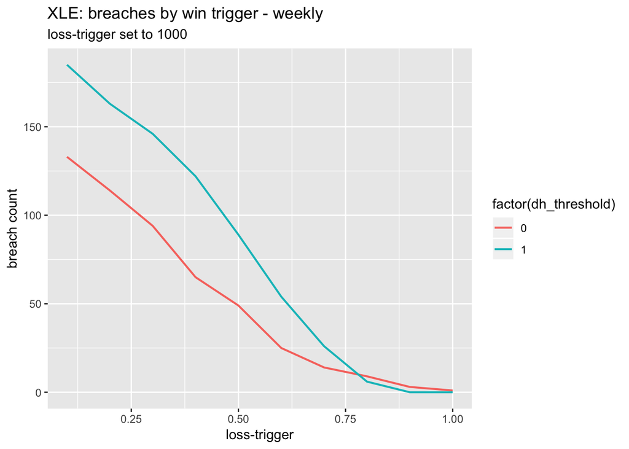

Finally, lets make sure that the breach counts were zero for the loss-trigger=1000 and win-trigger=1000.

```r
df_breach_count_weekly %>% filter(win_trigger == 1000)
```

```
## # A tibble: 2 x 3
## # Groups:   dh_threshold [2]
##   dh_threshold win_trigger breach_count
##          <dbl>       <dbl>        <int>
## 1            0        1000            0
## 2            1        1000            0
```

### All Underlyings Combined

We now combine the PNLs for all the underlyings and then check for optimal unwind levels.

#### weekly delta-hedged

```r
# weekly delta-hedged
df_sharpe_weekly %>%
    filter(dh_threshold == 0) %>%
    filter(sharpe == max(sharpe)) %>%
    select(dh_threshold, loss_trigger, win_trigger, sharpe)
```

```
## # A tibble: 1 x 4
##   dh_threshold loss_trigger win_trigger sharpe
##          <dbl>        <dbl>       <dbl>  <dbl>
## 1            0         1000        1000   1.27
```

#### weekly naked

```r
# weekly naked
df_sharpe_weekly %>%
    filter(dh_threshold == 1) %>%
    filter(sharpe == max(sharpe)) %>%
    select(dh_threshold, loss_trigger, win_trigger, sharpe)
```

```
## # A tibble: 1 x 4
##   dh_threshold loss_trigger win_trigger sharpe
##          <dbl>        <dbl>       <dbl>  <dbl>
## 1            1         2.75        1000  0.662
```

Instead of looking at just the single best win/loss trigger levels, it’s more robust to take the average of the top 10 unwind levels.

**Observations:**

1. It is clear that you should simply let your winners ride - there is no benefit to unwinding winners early.
2. The average optimal loss-trigger level is 2.275.

```r
# weekly naked - average of top 5 loss-trigger levels.
df_sharpe_weekly %>%
    filter(dh_threshold == 1) %>%
    top_n(10, sharpe) %>%
    select(dh_threshold, loss_trigger, win_trigger, avg_pnl, sharpe)
```

```
## # A tibble: 10 x 5
##    dh_threshold loss_trigger win_trigger avg_pnl sharpe
##           <dbl>        <dbl>       <dbl>   <dbl>  <dbl>
##  1            1         1.75         1     0.837  0.604
##  2            1         1.75      1000     0.842  0.607
##  3            1         2            1     0.872  0.602
##  4            1         2         1000     0.877  0.605
##  5            1         2.25         1     0.888  0.586
##  6            1         2.25      1000     0.893  0.590
##  7            1         2.5       1000     0.880  0.571
##  8            1         2.75         0.9   0.986  0.630
##  9            1         2.75         1     1.03   0.659
## 10            1         2.75      1000     1.04   0.662
```

```
## [1] "Average optimal loss-trigger:"
```

```
## [1] 2.275
```

#### visualization

As we can see, given a loss-trigger level of 2.5, there is no benenfit to early unwinding due to a win-trigger. The sharpe-ratio increases monotonically with a higher win-trigger.

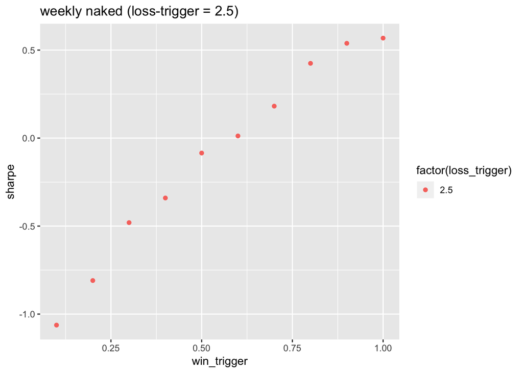

The following heat map corroborates the fact that unwinding winners early seems to be of no benefit.

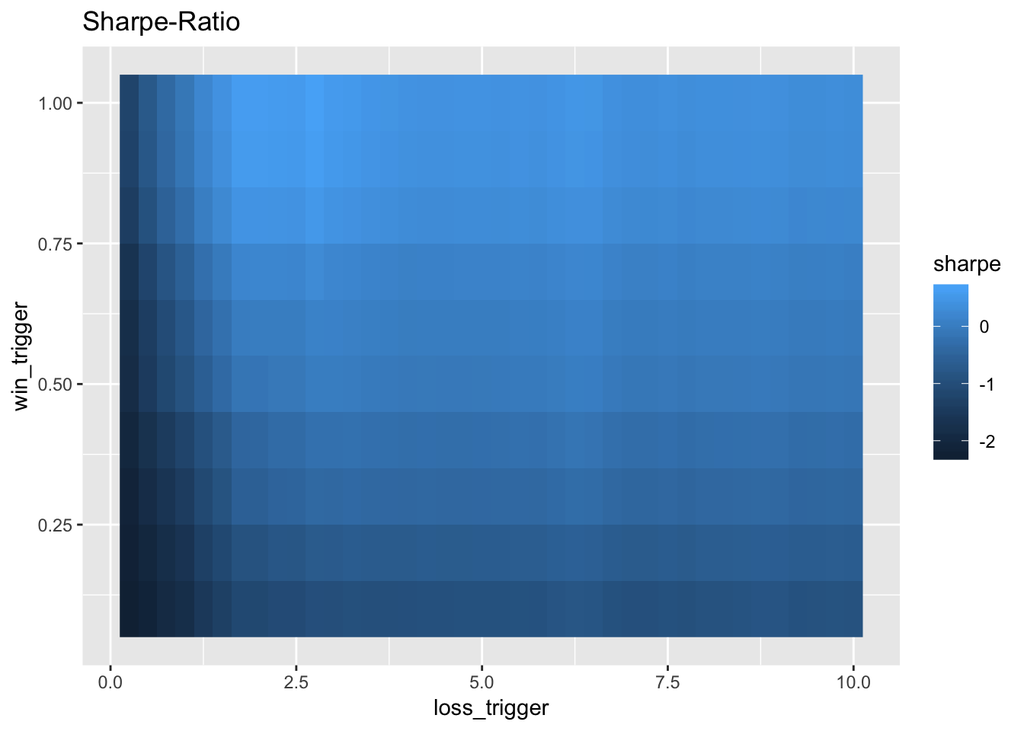

### Conclusions

There is no benefit to unwinding winners early, and there is a slight benefit to unwinding losses at 2.5x of initial premium.

The true value of this conclusion is no I don’t have to over manage my positions, which was taking a lot of time and energy, and was leading to poor investment outcomes. For the past couple of months, I probably would have been better off doing nothing.